# Treino: 29/01/2026

Yacht Club da Bahia – Desempenho dos Remadores vs. Vento e Corrente

Este relatório analisa o treino matinal de remo no Yacht Club da Bahia em **29 de Janeiro de 2026**. Os dados de GPS são baixados da plataforma Treinus e os dados ambientais da boia SIMCOSTA 515. O relatório calcula os trechos mais rápidos de 500 m em linha reta e examina como vento e corrente influenciaram cada desempenho.

## 1 – Pacotes

```r
library(yachtvaa)
library(dplyr)
library(sf)
library(ggplot2)
library(lubridate)
```

## 2 – Aquisição de dados

Baixa os registros GPS dos remadores e os dados da boia SIMCOSTA 515 em uma única chamada. Com `cache = TRUE` os dados são lidos do disco sem necessidade de autenticação.

```r
if (!params$cache) {
 session <- treinusr::treinus_auth()
}
use_cache <- params$cache
raw <- fetch_session_data(
  session = session,
  date        = params$date,
  start_time  = params$start_time,
  end_time    = params$end_time,
  athlete_ids = params$athlete_ids,
  cache       = use_cache,
  overwrite_db=!use_cache,
  use_memoise=FALSE
)

records <- raw$records
buoy    <- raw$buoy

# Filtro espacial: manter todos os registros para atletas que têm pelo menos
# alguns pontos dentro da área de estudo (ao invés de manter apenas os
# pontos dentro da bbox)
records_sf <- records_to_sf(records)
study_area <- sf::st_bbox(
  c(xmin = -38.61380, ymin = -13.00741,
    xmax = -38.46308, ymax = -12.81308),
  crs = 4326L
) |>
  sf::st_as_sfc() |>
  sf::st_transform(sf::st_crs(records_sf))

# Identificar atletas que têm pelo menos um ponto dentro da área de estudo
athletes_in_bbox <- records_sf[
  lengths(sf::st_intersects(records_sf, study_area)) > 0,
  "id_athlete"
]

# Manter todos os registros para esses atletas
records_sf <- records_sf[records_sf$id_athlete %in% athletes_in_bbox$id_athlete, ]

# Criar versão filtrada para cálculos de velocidade (apenas pontos dentro da bbox)
records_sf_bbox <- records_sf[
  lengths(sf::st_intersects(records_sf, study_area)) > 0,
]

# Documentação da lógica de filtragem espacial:
# 1. Identificamos atletas que têm pelo menos um ponto dentro da bbox
# 2. Mantemos TODOS os registros desses atletas (não apenas os dentro da bbox)
# 3. Para cálculos de velocidade (como no fast500), usamos apenas pontos dentro da bbox
# 4. Aplicamos pós-filtro no fast500 para garantir início/fim dos segmentos dentro da bbox
```

## 3 – Quem estava na água?

Nem todo atleta retornado pelo Treinus realmente remou – alguns podem ter registros GPS breves em terra. Mantemos apenas atletas com **pelo menos 100 pontos GPS** e percurso acumulado **superior a 200 m**.

```r
track_summary <- records_sf |>
  st_drop_geometry() |>
  summarise(
    n_fixes      = n(),
    first_fix    = min(timestamp),
    last_fix     = max(timestamp),
    duration_min = as.numeric(difftime(max(timestamp), min(timestamp),
                                       units = "mins")),
    .by = c(id_athlete, fullname_athlete)
  )

# Distância acumulada ponto a ponto por atleta
track_distance <- records_sf |>
  arrange(id_athlete, timestamp) |>
  mutate(
    coords = st_coordinates(geometry),
    x = coords[, 1],
    y = coords[, 2],
    .keep = "unused"
  ) |>
  st_drop_geometry() |>
  summarise(
    track_distance_m = sum(sqrt(diff(x)^2 + diff(y)^2)),
    .by = id_athlete
  )

track_summary <- track_summary |>
  left_join(track_distance, by = "id_athlete")

paddlers <- track_summary |>
  filter(n_fixes >= 100, track_distance_m >= 200)

paddlers |>
  arrange(desc(track_distance_m)) |>
  mutate(
    track_distance_km = round(track_distance_m / 1000, 1),
    duration_min      = round(duration_min, 0)
  ) |>
  select(fullname_athlete, n_fixes, duration_min, track_distance_km) |>
  knitr::kable(
    col.names = c("Atleta", "Pontos GPS", "Duração (min)", "Distância (km)"),
    caption   = "Atletas identificados na água"
  )
```

Atletas identificados na água

| Atleta | Pontos GPS | Duração (min) | Distância (km) |
| --- | --- | --- | --- |
| Victor Patiri | 1633 | 90 | 12.0 |
| Eduardo Valdes Sanchez | 638 | 80 | 9.8 |
| Stela de Sá Hama | 713 | 60 | 9.7 |
| Iris Azi | 1064 | 60 | 9.7 |
| Rosário Calmon | 651 | 60 | 9.7 |
| Verena Barbara Carneiro | 900 | 61 | 9.6 |
| Carita Souza | 808 | 61 | 9.6 |
| Fernanda Siqueira | 965 | 61 | 9.6 |
| Marina Cobalchini | 753 | 61 | 9.5 |
| Eduardo Leoni | 3600 | 60 | 9.0 |
| RICARDO RAPPEL | 904 | 62 | 9.0 |
| JULIANA RAPPEL | 592 | 62 | 9.0 |
| Renata Bandeira Machado Chaves | 712 | 60 | 8.9 |
| José Barretto | 3613 | 60 | 8.8 |
| Luiz Santos Souza Neto | 3046 | 51 | 8.4 |
| Patrícia IGLESIAS | 589 | 50 | 7.4 |

```r
records_sf <- records_sf |>
  filter(id_athlete %in% paddlers$id_athlete)

n_paddlers <- nrow(paddlers)
```

## 4 – Mapa dos trechos mais rápidos

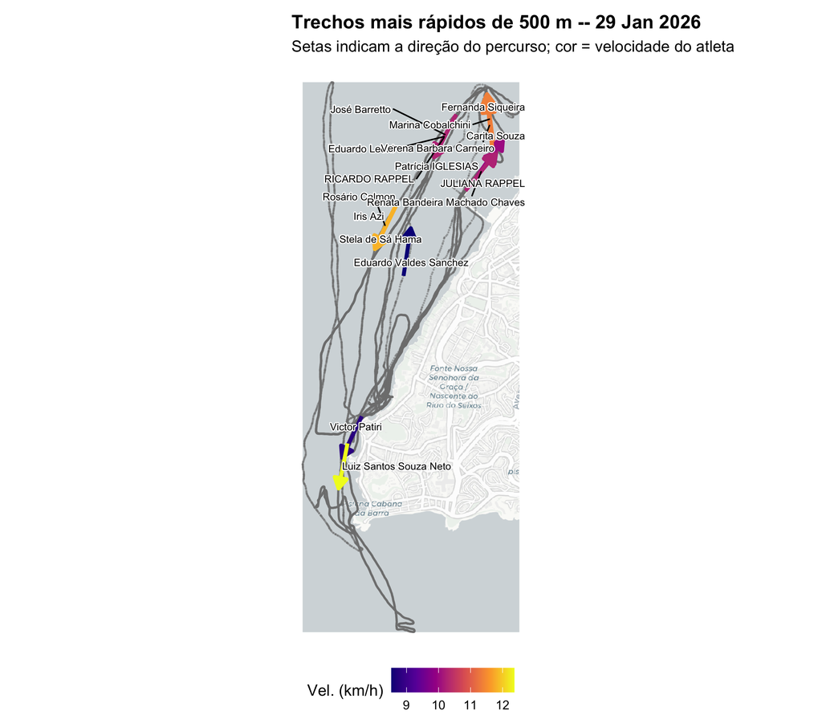

Trechos mais rápidos de 500 m em linha reta. Setas indicam a direção do percurso.

```r
arrow_df <- fast500 |>
  as_tibble()

basemap <- maptiles::get_tiles(records_sf, provider = "CartoDB.Positron",
                               crop = TRUE, verbose = FALSE)

ggplot() +
  tidyterra::geom_spatraster_rgb(data = basemap) +
  geom_sf(data = records_sf, colour = "grey50", size = 0.1, alpha = 0.4) +
  geom_segment(
    data = arrow_df,
    aes(x = start_x, y = start_y, xend = end_x, yend = end_y,
        colour = avg_speed_kmh),
    arrow = arrow(length = unit(0.3, "cm"), type = "closed"),
    linewidth = 1.3
  ) +
  ggrepel::geom_text_repel(
    data = arrow_df,
    aes(x = (start_x + end_x) / 2, y = (start_y + end_y) / 2,
        label = fullname_athlete),
    size = 2.5, max.overlaps = 20,
    bg.color = "white", bg.r = 0.15
  ) +
  scale_colour_viridis_c(option = "plasma", name = "Vel. (km/h)") +
  coord_sf(crs = sf::st_crs(records_sf)) +
  labs(
    title    = paste("Trechos mais rápidos de 500 m --", date_short),
    subtitle = "Setas indicam a direção do percurso; cor = velocidade do atleta"
  ) +
  theme_void(base_size = 11) +
  theme(
    legend.position = "bottom",
    plot.title      = element_text(face = "bold"),
    plot.margin     = margin(5, 5, 5, 5)
  )
```

## 5 – Condições da boia durante o treino

Interpolar os dados da boia em uma grade regular de 10 minutos.

```r
buoy_ip <- interpolate_buoy(buoy)
```

### Vento

```r
has_wind <- "wind_speed" %in% names(buoy_ip) &&
  any(!is.na(buoy_ip$wind_speed))
```

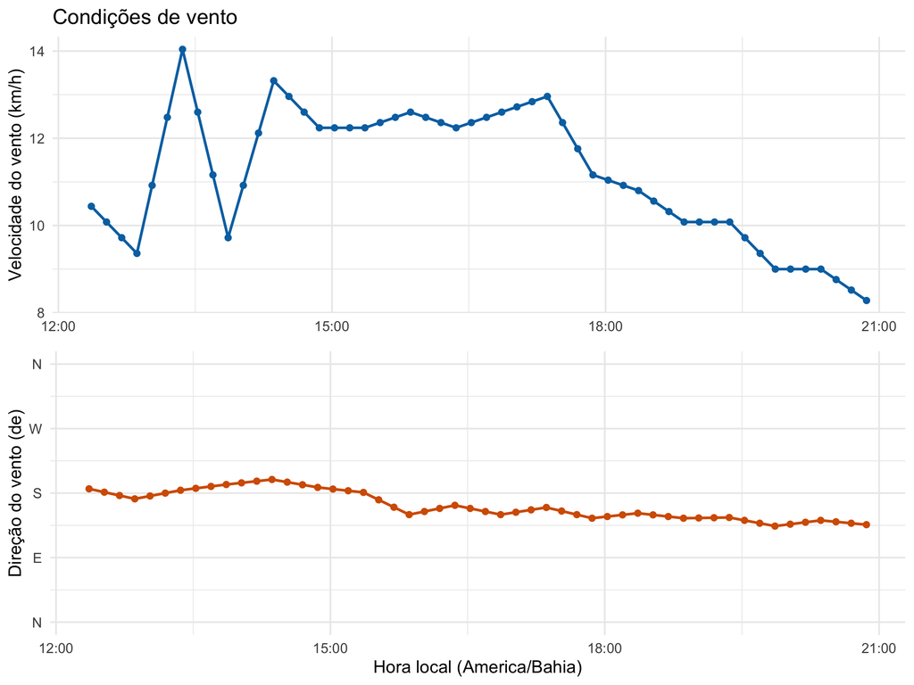

Velocidade e direção do vento registradas pela boia SIMCOSTA 515.

```r
buoy_wind <- buoy_ip |>
  filter(!is.na(wind_speed)) |>
  mutate(
    wind_speed_kmh = wind_speed * 3.6,
    local_time     = with_tz(datetime, tzone = "America/Bahia")
  )

p_speed <- ggplot(buoy_wind, aes(local_time, wind_speed_kmh)) +
  geom_line(linewidth = 0.8, colour = "#0072B2") +
  geom_point(size = 1.5, colour = "#0072B2") +
  labs(y = "Velocidade do vento (km/h)", x = NULL, title = "Condições de vento") +
  theme_minimal(base_size = 11)

p_dir <- ggplot(buoy_wind, aes(local_time, wind_direction)) +
  geom_line(linewidth = 0.8, colour = "#D55E00") +
  geom_point(size = 1.5, colour = "#D55E00") +
  scale_y_continuous(
    limits = c(0, 360),
    breaks = seq(0, 360, 90),
    labels = c("N", "E", "S", "W", "N")
  ) +
  labs(y = "Direção do vento (de)", x = "Hora local (America/Bahia)") +
  theme_minimal(base_size = 11)

gridExtra::grid.arrange(p_speed, p_dir, ncol = 1)
```

```r
cat("**Sem dados de vento disponíveis para este treino.** O vento será tratado como zero.\n")
```

### Corrente

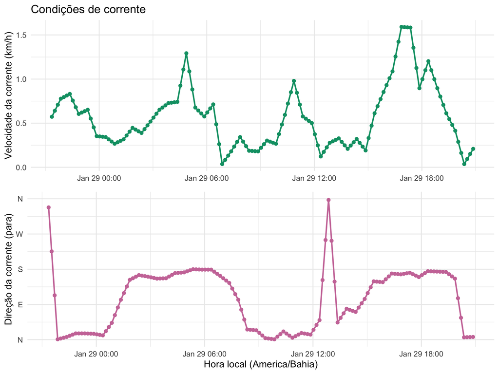

Velocidade e direção da corrente registradas pela boia 515.

```r
buoy_current <- buoy_ip |>
  filter(!is.na(current_speed_kmh)) |>
  mutate(local_time = with_tz(datetime, tzone = "America/Bahia"))

p_cspeed <- ggplot(buoy_current, aes(local_time, current_speed_kmh)) +
  geom_line(linewidth = 0.8, colour = "#009E73") +
  geom_point(size = 1.5, colour = "#009E73") +
  labs(y = "Velocidade da corrente (km/h)", x = NULL, title = "Condições de corrente") +
  theme_minimal(base_size = 11)

p_cdir <- ggplot(buoy_current, aes(local_time, current_direction)) +
  geom_line(linewidth = 0.8, colour = "#CC79A7") +
  geom_point(size = 1.5, colour = "#CC79A7") +
  scale_y_continuous(
    limits = c(0, 360),
    breaks = seq(0, 360, 90),
    labels = c("N", "E", "S", "W", "N")
  ) +
  labs(y = "Direção da corrente (para)", x = "Hora local (America/Bahia)") +
  theme_minimal(base_size = 11)

gridExtra::grid.arrange(p_cspeed, p_cdir, ncol = 1)
```

## 6 – Condições nos trechos mais rápidos

Associar cada segmento à observação mais próxima da boia via rolling join e calcular ângulos relativos de vento/corrente.

```r
buoy_for_match <- buoy_ip |>
  transmute(
    datetime,
    wind_direction_deg    = if ("wind_direction" %in% names(buoy_ip))
      wind_direction else NA_real_,
    wind_speed_kmh        = if ("wind_speed" %in% names(buoy_ip))
      wind_speed * 3.6 else NA_real_,
    current_direction_deg = current_direction,
    current_speed_kmh     = current_speed_kmh,
    wave_height,
    wave_direction
  )

matched <- match_buoy_to_segments(fast500, buoy_for_match)
```

Calcular ângulos relativos de vento/corrente e componentes ao longo do percurso. Quando dados de vento não estão disponíveis, são imputados como zero.

```r
conditions <- apparent_conditions(matched, impute_missing_wind = !has_wind)
```

### Corrente relativa ao rumo

Direção da corrente em relação ao rumo do trecho mais rápido de cada atleta. **Topo = corrente a favor** (de popa), **base = corrente contrária** (de proa). O raio indica a intensidade da corrente.

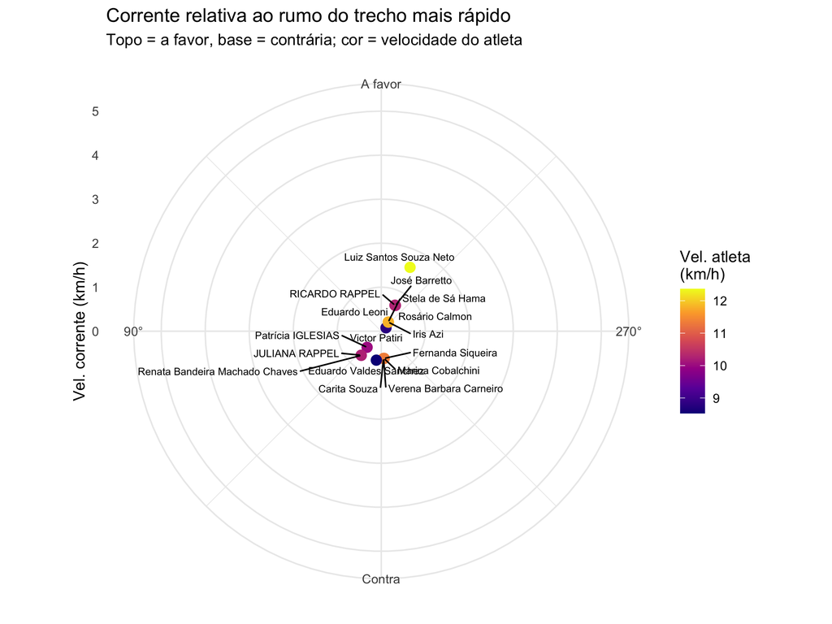

Corrente relativa ao rumo: topo = a favor, base = contrária. Raio = velocidade da corrente.

```r
current_polar <- conditions |>
  as_tibble() |>
  filter(!is.na(current_speed_kmh)) |>
  mutate(
    current_relative_deg = (current_direction_deg - bearing_deg) %% 360
  )

current_r_max <- max(5, max(current_polar$current_speed_kmh, na.rm = TRUE))

ggplot(current_polar, aes(x = current_relative_deg, y = current_speed_kmh)) +
  geom_point(aes(colour = avg_speed_kmh), size = 3) +
  ggrepel::geom_text_repel(
    aes(label = fullname_athlete),
    size = 2.5, max.overlaps = 20
  ) +
  coord_polar(start = 0, direction = -1) +
  scale_x_continuous(
    limits = c(0, 360),
    breaks = c(0, 90, 180, 270),
    labels = c("A favor", "90\u00b0", "Contra", "270\u00b0")
  ) +
  scale_y_continuous(limits = c(0, current_r_max)) +
  scale_colour_viridis_c(option = "plasma", name = "Vel. atleta\n(km/h)") +
  labs(
    title    = "Corrente relativa ao rumo do trecho mais rápido",
    subtitle = "Topo = a favor, base = contrária; cor = velocidade do atleta",
    x = NULL,
    y = "Vel. corrente (km/h)"
  ) +
  theme_minimal(base_size = 11)
```

### Vento relativo ao rumo

Mesma lógica aplicada ao vento. **Topo = vento a favor** (de popa), **base = vento contrário** (de proa).

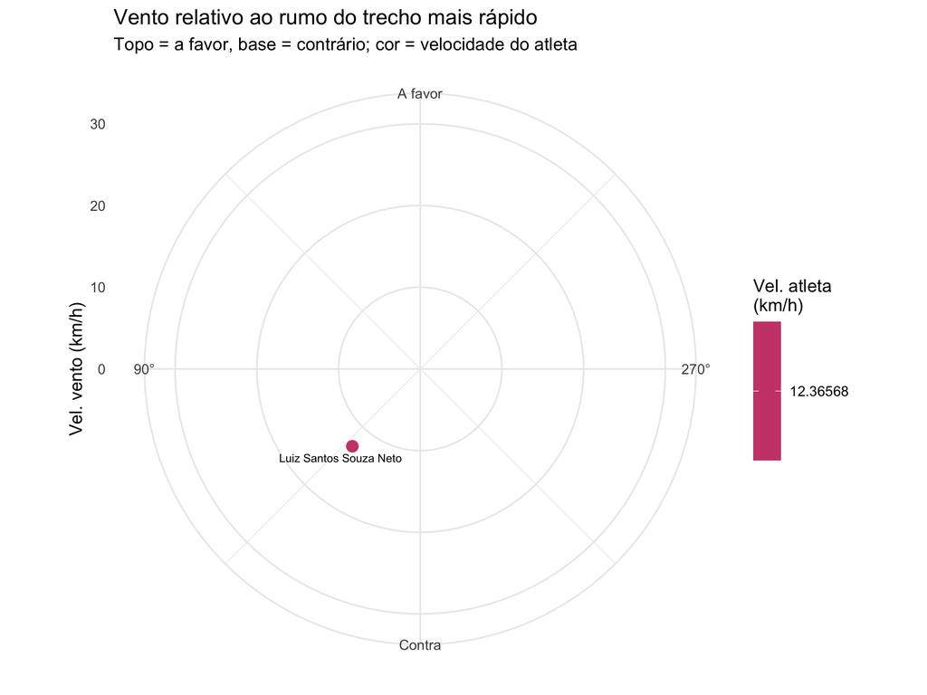

Vento relativo ao rumo: topo = a favor, base = contrário. Raio = velocidade do vento.

```r
wind_polar <- conditions |>
  as_tibble() |>
  filter(!is.na(wind_speed_kmh)) |>
  mutate(
    wind_relative_deg = (wind_direction_deg + 180 - bearing_deg) %% 360
  )

wind_r_max <- max(30, max(wind_polar$wind_speed_kmh, na.rm = TRUE))

ggplot(wind_polar, aes(x = wind_relative_deg, y = wind_speed_kmh)) +
  geom_point(aes(colour = avg_speed_kmh), size = 3) +
  ggrepel::geom_text_repel(
    aes(label = fullname_athlete),
    size = 2.5, max.overlaps = 20
  ) +
  coord_polar(start = 0, direction = -1) +
  scale_x_continuous(
    limits = c(0, 360),
    breaks = c(0, 90, 180, 270),
    labels = c("A favor", "90\u00b0", "Contra", "270\u00b0")
  ) +
  scale_y_continuous(limits = c(0, wind_r_max)) +
  scale_colour_viridis_c(option = "plasma", name = "Vel. atleta\n(km/h)") +
  labs(
    title    = "Vento relativo ao rumo do trecho mais rápido",
    subtitle = "Topo = a favor, base = contrário; cor = velocidade do atleta",
    x = NULL,
    y = "Vel. vento (km/h)"
  ) +
  theme_minimal(base_size = 11)
```

```r
cat("**Sem dados de vento disponíveis.** Gráfico polar de vento omitido.\n")
```

## 7 – Classificação

```r
league <- build_league_table(conditions, athlete_col = "fullname_athlete")
league_fmt <- format_league(league, top_n = 15)

league_fmt |>
  select(
    rank, fullname_athlete, predicted_time_fmt, avg_speed_kmh,
    wind_class, wind_component_kmh,
    current_class, current_component_kmh
  ) |>
  mutate(
    avg_speed_kmh         = round(avg_speed_kmh, 1),
    wind_component_kmh    = round(wind_component_kmh, 1),
    current_component_kmh = round(current_component_kmh, 1)
  ) |>
  knitr::kable(
    col.names = c(
      "Pos.", "Atleta", "Tempo", "Vel. (km/h)",
      "Vento", "Vento (km/h)", "Corrente", "Corrente (km/h)"
    ),
    caption = paste("Classificação: 500 m mais rápidos em", date_short)
  )
```

Classificação: 500 m mais rápidos em 29 Jan 2026

| Pos. | Atleta | Tempo | Vel. (km/h) | Vento | Vento (km/h) | Corrente | Corrente (km/h) |
| --- | --- | --- | --- | --- | --- | --- | --- |
| 1 | Luiz Santos Souza Neto | 2:25.6 | 12.4 | headwind | -9.5 | following | 1.5 |
| 2 | Stela de Sá Hama | 2:31.8 | 11.9 | crosswind_left | NA | following | 0.2 |
| 3 | Rosário Calmon | 2:32.0 | 11.8 | crosswind_left | NA | following | 0.2 |
| 4 | Iris Azi | 2:32.5 | 11.8 | crosswind_left | NA | following | 0.2 |
| 5 | Marina Cobalchini | 2:38.3 | 11.4 | crosswind_left | NA | opposing | -0.6 |
| 6 | Carita Souza | 2:38.4 | 11.4 | crosswind_left | NA | opposing | -0.6 |
| 7 | Fernanda Siqueira | 2:38.4 | 11.4 | crosswind_left | NA | opposing | -0.6 |
| 8 | Verena Barbara Carneiro | 2:38.8 | 11.3 | crosswind_left | NA | opposing | -0.6 |
| 9 | Eduardo Leoni | 2:55.4 | 10.3 | crosswind_left | NA | following | 0.6 |
| 10 | JULIANA RAPPEL | 2:55.8 | 10.2 | crosswind_left | NA | opposing | -0.5 |
| 11 | RICARDO RAPPEL | 2:56.1 | 10.2 | crosswind_left | NA | following | 0.6 |
| 12 | José Barretto | 2:56.2 | 10.2 | crosswind_left | NA | following | 0.6 |
| 13 | Renata Bandeira Machado Chaves | 2:56.6 | 10.2 | crosswind_left | NA | opposing | -0.5 |
| 14 | Patrícia IGLESIAS | 2:59.9 | 10.0 | crosswind_left | NA | opposing | -0.4 |
| 15 | Victor Patiri | 3:24.6 | 8.8 | crosswind_left | NA | cross_left | 0.1 |

## 8 – Resumo do treino

```r
current_summary <- buoy_current |>
  summarise(
    mean_speed = round(mean(current_speed_kmh, na.rm = TRUE), 2),
    max_speed  = round(max(current_speed_kmh, na.rm = TRUE), 2),
    mean_dir   = round(mean(current_direction, na.rm = TRUE), 0)
  )

winner      <- league_fmt$fullname_athlete[1]
winner_time <- league_fmt$predicted_time_fmt[1]
winner_kmh  <- round(league_fmt$avg_speed_kmh[1], 1)

if (has_wind) {
  wind_summary <- buoy_wind |>
    summarise(
      mean_speed = round(mean(wind_speed_kmh, na.rm = TRUE), 1),
      max_speed  = round(max(wind_speed_kmh, na.rm = TRUE), 1),
      mean_dir   = round(mean(wind_direction, na.rm = TRUE), 0)
    )
  wind_line <- sprintf(
    "- **Vento:** média %s km/h (máx %s), predominante de %s°",
    wind_summary$mean_speed, wind_summary$max_speed, wind_summary$mean_dir
  )
} else {
  wind_line <- "- **Vento:** sem dados disponíveis (imputado como zero)"
}

cat(sprintf(
  "**Resumo do treino:**\n\n
- **Data:** %s
- **Atletas na água:** %d
%s
- **Corrente:** média %s km/h (máx %s), fluindo para %s°
- **500 m mais rápido:** %s em %s (%s km/h)\n",
  date_label,
  n_paddlers,
  wind_line,
  current_summary$mean_speed, current_summary$max_speed, current_summary$mean_dir,
  winner, winner_time, winner_kmh
))
```

**Resumo do treino:**

- **Data:** 29/01/2026
- **Atletas na água:** 16
- **Vento:** média 11.2 km/h (máx 14), predominante de 163°
- **Corrente:** média 0.57 km/h (máx 1.59), fluindo para 105°
- **500 m mais rápido:** Luiz Santos Souza Neto em 2:25.6 (12.4 km/h)